# How Has The Game Changed in Professional Basketaball?

#### A Data Analysis by Ethan Jaffee, Christopher Witte, & Ashwin Rajan

# Part 1: Intro

### Section 1.1: Project Intro

In our final tutorial we will be analyzing data from National Basketball Association (NBA) games between 2004 and 2021 to see how the sport has changed and will apply knowledge we gained in CMSC320 to gain a deeper insight into how professional basketball has evolved between the early 2000s and now.

### Section 1.2: Background Info

The NBA, or the National Basketball Association, is the world’s premier professional basketball league and features some of the world's greatest athletes. Like other sports the NBA has undergone a statistical revolution, in which coaches and players have begun analyzing the sport using statistics in an attempt to improve and make the game more efficient. If you are interested in the specifics of this we recommend you read this article https://qz.com/1104922/data-analytics-have-revolutionized-the-nba/ . By looking at the outcomes of games over the years we hope to be able to see how this change has affected the game and what specific aspects of the game have been changed.

### Section 1.3: Libraries

Below are the python libraries we used while performing the analyses we used in our project.

```python
import pandas as pd
import matplotlib.pyplot as plt
import numpy as np
import statistics
import seaborn as sns
from statsmodels.formula.api import ols
```

# Part 2: The Data

### Section 2.1: Getting started!

The first thing we will do is take our csv and load it into a pandas dataframe, luckily pandas has a built in method to help us do that!

```python
df = pd.read_csv("games.csv")
df.head()
```

|  | GAME_DATE_EST | GAME_ID | GAME_STATUS_TEXT | HOME_TEAM_ID | VISITOR_TEAM_ID | SEASON | TEAM_ID_home | PTS_home | FG_PCT_home | FT_PCT_home | ... | AST_home | REB_home | TEAM_ID_away | PTS_away | FG_PCT_away | FT_PCT_away | FG3_PCT_away | AST_away | REB_away | HOME_TEAM_WINS |
| --- | --- | --- | --- | --- | --- | --- | --- | --- | --- | --- | --- | --- | --- | --- | --- | --- | --- | --- | --- | --- | --- |
| 0 | 2021-11-17 | 22100213 | Final | 1610612766 | 1610612764 | 2021 | 1610612766 | 97.0 | 0.438 | 0.500 | ... | 30.0 | 59.0 | 1610612764 | 87.0 | 0.367 | 0.813 | 0.190 | 23.0 | 48.0 | 1 |
| 1 | 2021-11-17 | 22100214 | Final | 1610612765 | 1610612754 | 2021 | 1610612765 | 97.0 | 0.425 | 0.750 | ... | 16.0 | 42.0 | 1610612754 | 89.0 | 0.418 | 0.737 | 0.243 | 14.0 | 43.0 | 1 |
| 2 | 2021-11-17 | 22100215 | Final | 1610612737 | 1610612738 | 2021 | 1610612737 | 110.0 | 0.506 | 0.833 | ... | 28.0 | 40.0 | 1610612738 | 99.0 | 0.440 | 0.824 | 0.268 | 24.0 | 42.0 | 1 |
| 3 | 2021-11-17 | 22100216 | Final | 1610612751 | 1610612739 | 2021 | 1610612751 | 109.0 | 0.458 | 0.840 | ... | 29.0 | 47.0 | 1610612739 | 99.0 | 0.393 | 0.857 | 0.250 | 20.0 | 50.0 | 1 |
| 4 | 2021-11-17 | 22100217 | Final | 1610612748 | 1610612740 | 2021 | 1610612748 | 113.0 | 0.483 | 0.824 | ... | 29.0 | 39.0 | 1610612740 | 98.0 | 0.440 | 0.786 | 0.286 | 18.0 | 38.0 | 1 |

5 rows × 21 columns

As observed above, the dataset has many catagories that can be useful for our analysis. The creator of the dataset has made columns that are very specific so people like us can get game data as specific as we desire. For example, we can look at points, field goal percentage, free throw percentage, assists, and rebounds for both the home and away team indivudually.

Next we are going to add the following columns to help with our analysis later:

- Combine the home and away score for each game to have the total score for each game.
- Combine the home and away Field Goal Percentage for an Average Field Goal Percentage for each game.
- Combine the home and away Three Point Percentage for an Average Three Point Percentage for each game.
- Combine the home and away Free Throw Percentage for an Average Free Throw Percentage for each game.
- Combine the home and away assists for a total number of assists for each game.
- Combine the home and away rebounds for a total number of rebounds for each game.
- Add a column that has just the year the game is played.

```python
df['total_score'] = df['PTS_home'] + df['PTS_away']
df['avg_FG_PCT'] = (df['FG_PCT_home'] + df['FG_PCT_away']) / 2
df['avg_FG3_PCT'] = (df['FG3_PCT_home'] + df['FG3_PCT_away']) / 2
df['avg_FT_PCT'] = (df['FT_PCT_home'] + df['FT_PCT_away']) / 2
df['total_assists']  = df['AST_home'] + df['AST_away']
df['total_rebounds'] = df['REB_home'] + df['REB_away']
def to_integer(dt_time):
    return 1 *dt_time.year
df['year'] = to_integer(pd.to_datetime(df['GAME_DATE_EST']).dt)
df.head()
```

|  | GAME_DATE_EST | GAME_ID | GAME_STATUS_TEXT | HOME_TEAM_ID | VISITOR_TEAM_ID | SEASON | TEAM_ID_home | PTS_home | FG_PCT_home | FT_PCT_home | ... | AST_away | REB_away | HOME_TEAM_WINS | total_score | avg_FG_PCT | avg_FG3_PCT | avg_FT_PCT | total_assists | total_rebounds | year |
| --- | --- | --- | --- | --- | --- | --- | --- | --- | --- | --- | --- | --- | --- | --- | --- | --- | --- | --- | --- | --- | --- |
| 0 | 2021-11-17 | 22100213 | Final | 1610612766 | 1610612764 | 2021 | 1610612766 | 97.0 | 0.438 | 0.500 | ... | 23.0 | 48.0 | 1 | 184.0 | 0.4025 | 0.2515 | 0.6565 | 53.0 | 107.0 | 2021 |
| 1 | 2021-11-17 | 22100214 | Final | 1610612765 | 1610612754 | 2021 | 1610612765 | 97.0 | 0.425 | 0.750 | ... | 14.0 | 43.0 | 1 | 186.0 | 0.4215 | 0.2645 | 0.7435 | 30.0 | 85.0 | 2021 |
| 2 | 2021-11-17 | 22100215 | Final | 1610612737 | 1610612738 | 2021 | 1610612737 | 110.0 | 0.506 | 0.833 | ... | 24.0 | 42.0 | 1 | 209.0 | 0.4730 | 0.3095 | 0.8285 | 52.0 | 82.0 | 2021 |
| 3 | 2021-11-17 | 22100216 | Final | 1610612751 | 1610612739 | 2021 | 1610612751 | 109.0 | 0.458 | 0.840 | ... | 20.0 | 50.0 | 1 | 208.0 | 0.4255 | 0.3125 | 0.8485 | 49.0 | 97.0 | 2021 |
| 4 | 2021-11-17 | 22100217 | Final | 1610612748 | 1610612740 | 2021 | 1610612748 | 113.0 | 0.483 | 0.824 | ... | 18.0 | 38.0 | 1 | 211.0 | 0.4615 | 0.3305 | 0.8050 | 47.0 | 77.0 | 2021 |

5 rows × 28 columns

# Part 3: Analysis and Visuals

Here we are going to make some plots to see how the data changes in several different catagories.

### Section 3.1: Total Scoring by Year

First we will make a really simple plot to see how scoring has changed over time. We will make a plot that charts scoring vs year.

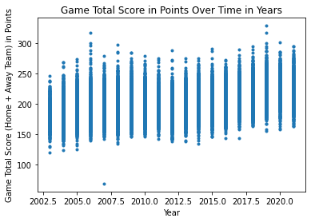

```python
plt.plot(df['year'], df['total_score'], '.')
plt.xlabel("Year")
plt.ylabel("Game Total Score (Home + Away Team) in Points")
plt.title("Game Total Score in Points Over Time in Years")
```

From this chart we can see a general uptick in scoring during our time period. As we look at the data points as time goes on, the lower and higher bound both increase over time. While this does give us some insight, all these data points can make it hard to visualize exactly what we need to. This is where using an average will be useful!

### Section 3.2: Average Scoring per Year

Let’s get the average score per year so there's only one data point for each year.

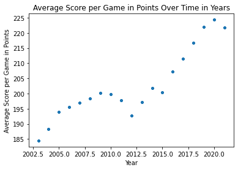

```python
df['mean'] = df.groupby('year').total_score.transform(lambda s: s.mean())
plt.plot(df['year'], df['mean'], '.')
plt.xlabel("Year")
plt.ylabel("Average Score per Game in Points")
plt.title("Average Score per Game in Points Over Time in Years")
```

Looking at the plot above, it is evident that the average scoring per game increases over time. Since this plot shows the averages, the amount of data points in the visualization decreases significantly. While an average may not show the entire picture as well as a plot with every game as a data point, it is still a reliable method that makes viewing the pattern a lot easier.

We now have looked at two plots that show how scoring has increased overtime. However, in the NBA there are a few different ways to score that were mentioned earlier being three point shots, two point shots, and free throws. Each of these may have increased differently, with one having more impact than another depending on the year. This is why it is important to look at plots of each of these individually.

### Section 3.3: Field Goal Percentage

Field Goal Percentage(FG%), according to Basketball-Reference.com is the ratio of field goals made to field goals attempted. This includes all shots including dunks, lay-ups, two-point shots, and three-point shots. Let's see how it has changed overtime!

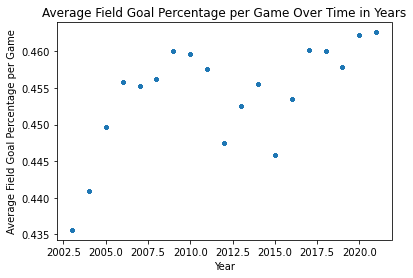

```python
df['mean'] = df.groupby('year').avg_FG_PCT.transform(lambda s: s.mean())
plt.plot(df['year'], df['mean'], '.')
plt.xlabel("Year")
plt.ylabel("Average Field Goal Percentage per Game")
plt.title("Average Field Goal Percentage per Game Over Time in Years")
```

As shown in the plot above, aside from a few irregular years the field goal percentage generally has increased over the years. Since this statistic includes three point shots and two point shots, considering the significant increase on the graph, it is likely that both types of shots’ frequency has increased. This could be due to several reasons. For example, the talent in the league may have increased with time, so players would generally make more baskets than before. Another reason is that coaches emphasize taking better shots, so if teams are taking better shots it is more likely that a higher ratio of them are going in.

### Section 3.4: Three-Point Shot Percentage

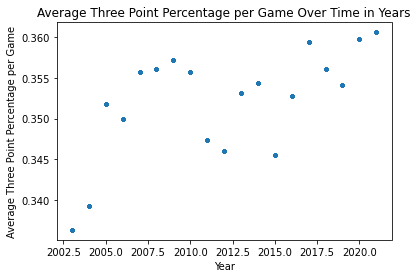

```python
df['mean'] = df.groupby('year').avg_FG3_PCT.transform(lambda s: s.mean())
plt.plot(df['year'], df['mean'], '.')
plt.xlabel("Year")
plt.ylabel("Average Three Point Percentage per Game")
plt.title("Average Three Point Percentage per Game Over Time in Years")
```

The graph above shows that the three point shot percentage has increased over time. This graph is interesting because it dissects the previous field goal percentage plot to only have specifically three point shots. It is a smart feature for dataset curators to do this as it allows the analysis to become more in depth as we can really look at the different types of scoring occurring in the game. Once again, a reason for the increase in three point percentage could be due to coaches emphasizing taking better shots. If players wait to shoot for a good opportunity, it is likely that more will go in. Another aspect worth mentioning is that over time the three point shot has become more and more essential to the game of basketball. While our dataset does not include NBA data from before the three point shot, it likely has become more and more used after its integration because not only have players improved to hit them frequently, but it also has increased the overall scoring in games.

### Section 3.5: Free Throw Percentage

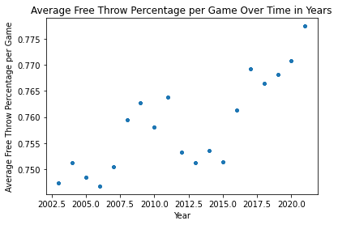

```python
df['mean'] = df.groupby('year').avg_FT_PCT.transform(lambda s: s.mean())
plt.plot(df['year'], df['mean'], '.')
plt.xlabel("Year")
plt.ylabel("Average Free Throw Percentage per Game")
plt.title("Average Free Throw Percentage per Game Over Time in Years")
```

### Section 3.6: Assists

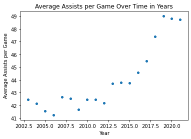

```python
df['mean'] = df.groupby('year').total_assists.transform(lambda s: s.mean())
plt.plot(df['year'], df['mean'], '.')
plt.xlabel("Year")
plt.ylabel("Average Assists per Game")
plt.title("Average Assists per Game Over Time in Years")
```

As evidenced by the plot above, we can see a drastic increase in average assists per game from 2004 to 2021. This relates to the idea that basketball has become even more of a team sport over the years, and that teams are more reliant on ball movement (as opposed to a series of 1v1s between two teams’ best players). This is further proved by the successes of the Spurs and Warriors dynasties, both of whose philosophies stress the importance of team basketball and ball movement. This rise in ball movement really began just before our data, in 2001-02. The reason for this was the change in legality of zone defense, allowing multiple defenders to team up on a single offensive player which was previously penalized for “illegal defense.”

### Section 3.7: Rebounds

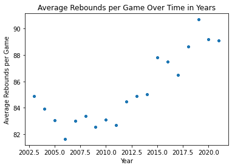

```python
df['mean'] = df.groupby('year').total_rebounds.transform(lambda s: s.mean())
plt.plot(df['year'], df['mean'], '.')
plt.xlabel("Year")
plt.ylabel("Average Rebounds per Game")
plt.title("Average Rebounds per Game Over Time in Years")
```

From looking at the plot above, we can see there has been an overall increase in the average number of rebounds per game, but from the previous graphs we know that average shooting percentages are also on the rise. We can therefore conclude that the pace of play of the game has increased by a fairly significant amount over the years (4-5 possessions per game). This increase in average rebounds per game also helps reinforce why scoring has increased over the years, along with the increase in average shooting percentages. Pace of play is also something recently stressed in coaching by some of the most successful teams, like the Warriors, Suns, Nets, and Bucks (though there are other teams who play with the opposite approach, as strategy depends on team composition).

## Looking at Home Teams vs Away Teams:

Clearly a lot has changed over the years in the NBA, if you want to know how to read all the above analysis! One interesting thing we thought could come from the data we have here is looking to see the effect of home court advantage. Home court advantage is the idea that the home team will be able to play better because they are more used to the court they are playing on and that the fans there will support them. We wanted to look at how being the home team has acaullty affected the certain statistics of teams, and if home court advantage has become more or less important through the years.

### Section 3.8: Total Points - Home vs Away

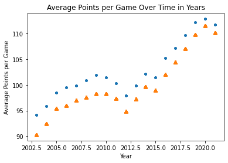

```python
df['home_mean'] = df.groupby('year').PTS_home.transform(lambda s: s.mean())
df['away_mean'] = df.groupby('year').PTS_away.transform(lambda s: s.mean())
plt.plot(df['year'], df['home_mean'], '.')
plt.plot(df['year'], df['away_mean'], '^')
plt.xlabel("Year")
plt.ylabel("Average Points per Game")
plt.title("Average Points per Game Over Time in Years")
```

As the above graph indicates, there is a consistent gap between home and away averages for scoring. This gap has, however, gotten closer in recent years, showing home court advantage to be less impactful in recent seasons. One of the reasons for this may be that sports psychology and players’ mental states have been getting more attention, and players train their minds to be more prepared for stressful moments in games. In 2020 specifically, a lack of home court advantage may have also been impacted by a complete lack of fans in arenas due to the Covid-19 pandemic.

### Section 3.9: Field Goal Percentage - Home vs Away

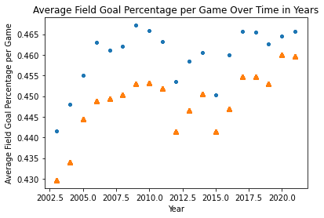

```python
df['home_mean'] = df.groupby('year').FG_PCT_home.transform(lambda s: s.mean())
df['away_mean'] = df.groupby('year').FG_PCT_away.transform(lambda s: s.mean())
plt.plot(df['year'], df['home_mean'], '.')
plt.plot(df['year'], df['away_mean'], '^')
plt.xlabel("Year")
plt.ylabel("Average Field Goal Percentage per Game")
plt.title("Average Field Goal Percentage per Game Over Time in Years")
```

When looking at the above graphs we see that much like the other home vs away comparisons the home team has always been above, by again we see that in recent years the advantage that home teams have is waning. This can be attributed to the factors discussed in our analysis about general field goal percentages, and the sharp decrease in gap between home and away that we see in recent years (specifically 2020 and 2021) is that teams have been playing in stadiums without fans due to the COVID-19 pandemic, so being in your home stadium would have less of an effect.

### Section 3.10: Three Point Percentage - Home vs Away

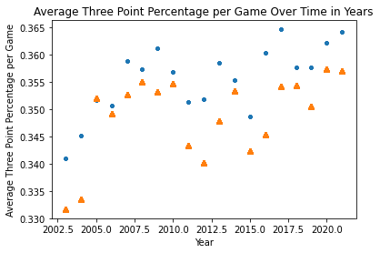

```python
df['home_mean'] = df.groupby('year').FG3_PCT_home.transform(lambda s: s.mean())
df['away_mean'] = df.groupby('year').FG3_PCT_away.transform(lambda s: s.mean())
plt.plot(df['year'], df['home_mean'], '.')
plt.plot(df['year'], df['away_mean'], '^')
plt.xlabel("Year")
plt.ylabel("Average Three Point Percentage per Game")
plt.title("Average Three Point Percentage per Game Over Time in Years")
```

This graph is interesting and hard to do an analysis on due to its inconsistency. In some years the home and away teams have very similar three point shot percentages, but in other years it is significantly different. Further, it goes back and forth between these throughout the timeframe that our data has. While there are more scenarios in which the home team has had higher three point percentages, there is not an identifiable trend over time. Because of this, I would not confidently say that a home team or away team is more likely to have an advantage when it comes to three point shots.

### Section 3.11: Free Throw Percentage - Home vs Away

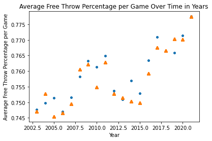

```python
df['home_mean'] = df.groupby('year').FT_PCT_home.transform(lambda s: s.mean())
df['away_mean'] = df.groupby('year').FT_PCT_away.transform(lambda s: s.mean())
plt.plot(df['year'], df['home_mean'], '.')
plt.plot(df['year'], df['away_mean'], '^')
plt.xlabel("Year")
plt.ylabel("Average Free Throw Percentage per Game")
plt.title("Average Free Throw Percentage per Game Over Time in Years")
```

As shown by the graph above, there has not ever been consistency in home vs away free throw percentages, and in some years the away teams even shoot a higher percentage than the home teams do. This seems to show that home court advantage simply does not apply to free throw percentage for some reason, though we cannot really say why.

### Section 3.12: Assists - Home vs Away

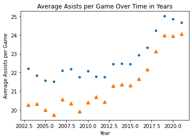

```python
df['home_mean'] = df.groupby('year').AST_home.transform(lambda s: s.mean())
df['away_mean'] = df.groupby('year').AST_away.transform(lambda s: s.mean())
plt.plot(df['year'], df['home_mean'], '.')
plt.plot(df['year'], df['away_mean'], '^')
plt.xlabel("Year")
plt.ylabel("Average Assists per Game")
plt.title("Average Asists per Game Over Time in Years")
```

The plot above has an interesting trend that is useful in analyzing the existence of a home team advantage in a given NBA game. While the number of assists for both teams have increased over time, they have not proportionally. Looking at the data points in the graph, over time they get closer together. This could mean that overtime there has been less and less of a home team advantage overtime.

### Section 3.13: Rebounds Percentage - Home vs Away

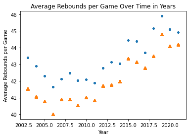

```python
df['home_mean'] = df.groupby('year').REB_home.transform(lambda s: s.mean())
df['away_mean'] = df.groupby('year').REB_away.transform(lambda s: s.mean())
plt.plot(df['year'], df['home_mean'], '.')
plt.plot(df['year'], df['away_mean'], '^')
plt.xlabel("Year")
plt.ylabel("Average Rebounds per Game")
plt.title("Average Rebounds per Game Over Time in Years")
```

# Part 4: Machine Learning Algorithm

In this section of the project we are performing a linear regression and analyzing the residuals. First, it is important to define these terms. According to statisticshowto.com, linear regression is modeling the relationship between a scalar response and one or more explanatory variables. Residuals are the difference between any data point and the regression line. We are computing this to see how different aspects of the NBA have changed overtime.

### Section 4.1: Regression of Total Scoring by Year

First we will calculate a regression to see how scoring has changed over time.

```python
line = ols(formula = "total_score ~ year ", data = df).fit()
print (line.summary())
```

```
                            OLS Regression Results
==============================================================================
Dep. Variable:            total_score   R-squared:                       0.168
Model:                            OLS   Adj. R-squared:                  0.168
Method:                 Least Squares   F-statistic:                     5031.
Date:                Sun, 19 Dec 2021   Prob (F-statistic):               0.00
Time:                        11:26:40   Log-Likelihood:            -1.1091e+05
No. Observations:               24925   AIC:                         2.218e+05
Df Residuals:                   24923   BIC:                         2.218e+05
Df Model:                           1
Covariance Type:            nonrobust
==============================================================================
                 coef    std err          t      P>|t|      [0.025      0.975]
------------------------------------------------------------------------------
Intercept  -3383.0612     50.554    -66.920      0.000   -3482.149   -3283.973
year           1.7821      0.025     70.933      0.000       1.733       1.831
==============================================================================
Omnibus:                      490.502   Durbin-Watson:                   1.894
Prob(Omnibus):                  0.000   Jarque-Bera (JB):              572.088
Skew:                           0.296   Prob(JB):                    5.92e-125
Kurtosis:                       3.448   Cond. No.                     7.75e+05
==============================================================================

Notes:
[1] Standard Errors assume that the covariance matrix of the errors is correctly specified.
[2] The condition number is large, 7.75e+05. This might indicate that there are
strong multicollinearity or other numerical problems.
```

Annually, scoring in the NBA increases by approximately 1.7821 points.

Now we will make a violin plot of the residuals from our regression of average scoring vs year

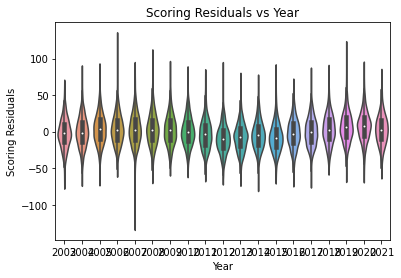

```python
m = line.params.year
a = line.params.Intercept

df['expected'] = 0.0
for i, j in df.iterrows():
    expectation = m * (j['year']) + a
    df.at[i, 'expected'] = expectation
df['residuals'] = df['total_score'] - df['expected']

sns.violinplot(x = 'year', y = 'residuals', data = df)
plt.title("Scoring Residuals vs Year")
plt.xlabel("Year")
plt.ylabel("Scoring Residuals")
```

### Section 4.2: Regression of Field Goal Percentage

```python
line = ols(formula = "avg_FG_PCT ~ year ", data = df).fit()
print (line.summary())
```

```
                            OLS Regression Results
==============================================================================
Dep. Variable:             avg_FG_PCT   R-squared:                       0.007
Model:                            OLS   Adj. R-squared:                  0.007
Method:                 Least Squares   F-statistic:                     164.8
Date:                Sun, 19 Dec 2021   Prob (F-statistic):           1.33e-37
Time:                        11:26:45   Log-Likelihood:                 44649.
No. Observations:               24925   AIC:                        -8.929e+04
Df Residuals:                   24923   BIC:                        -8.928e+04
Df Model:                           1
Covariance Type:            nonrobust
==============================================================================
                 coef    std err          t      P>|t|      [0.025      0.975]
------------------------------------------------------------------------------
Intercept     -0.8096      0.098     -8.221      0.000      -1.003      -0.617
year           0.0006   4.89e-05     12.837      0.000       0.001       0.001
==============================================================================
Omnibus:                        5.122   Durbin-Watson:                   1.933
Prob(Omnibus):                  0.077   Jarque-Bera (JB):                4.889
Skew:                           0.007   Prob(JB):                       0.0868
Kurtosis:                       2.933   Cond. No.                     7.75e+05
==============================================================================

Notes:
[1] Standard Errors assume that the covariance matrix of the errors is correctly specified.
[2] The condition number is large, 7.75e+05. This might indicate that there are
strong multicollinearity or other numerical problems.
```

```
<module 'matplotlib.pyplot' from '/Library/Frameworks/Python.framework/Versions/3.9/lib/python3.9/site-packages/matplotlib/pyplot.py'>
```

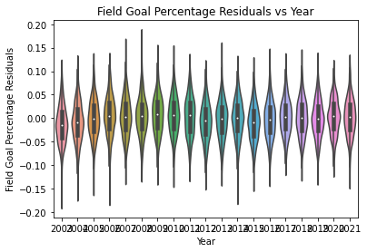

```python
m = line.params.year
a = line.params.Intercept

df['expected'] = 0.0
for i, j in df.iterrows():
    expectation = m * (j['year']) + a
    df.at[i, 'expected'] = expectation
df['residuals'] = df['avg_FG_PCT'] - df['expected']

sns.violinplot(x = 'year', y = 'residuals', data = df)
plt.title("Field Goal Percentage Residuals vs Year")
plt.xlabel("Year")
plt.ylabel("Field Goal Percentage Residuals")
plt
```

### Section 4.3: Residuals of Three Point Shot Percentage

```python
line = ols(formula = "avg_FG3_PCT ~ year ", data = df).fit()
print (line.summary())
```

```
                            OLS Regression Results
==============================================================================
Dep. Variable:            avg_FG3_PCT   R-squared:                       0.001
Model:                            OLS   Adj. R-squared:                  0.001
Method:                 Least Squares   F-statistic:                     35.00
Date:                Sun, 19 Dec 2021   Prob (F-statistic):           3.35e-09
Time:                        11:26:50   Log-Likelihood:                 27884.
No. Observations:               24925   AIC:                        -5.576e+04
Df Residuals:                   24923   BIC:                        -5.575e+04
Df Model:                           1
Covariance Type:            nonrobust
==============================================================================
                 coef    std err          t      P>|t|      [0.025      0.975]
------------------------------------------------------------------------------
Intercept     -0.7888      0.193     -4.088      0.000      -1.167      -0.411
year           0.0006   9.59e-05      5.916      0.000       0.000       0.001
==============================================================================
Omnibus:                      114.672   Durbin-Watson:                   1.958
Prob(Omnibus):                  0.000   Jarque-Bera (JB):              153.285
Skew:                           0.057   Prob(JB):                     5.18e-34
Kurtosis:                       3.367   Cond. No.                     7.75e+05
==============================================================================

Notes:
[1] Standard Errors assume that the covariance matrix of the errors is correctly specified.
[2] The condition number is large, 7.75e+05. This might indicate that there are
strong multicollinearity or other numerical problems.
```

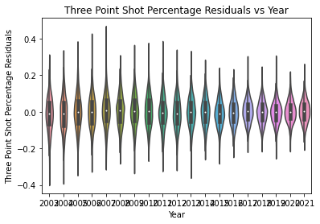

```python
m = line.params.year
a = line.params.Intercept

df['expected'] = 0.0
for i, j in df.iterrows():
    expectation = m * (j['year']) + a
    df.at[i, 'expected'] = expectation
df['residuals'] = df['avg_FG3_PCT'] - df['expected']

sns.violinplot(x = 'year', y = 'residuals', data = df)
plt.title("Three Point Shot Percentage Residuals vs Year")
plt.xlabel("Year")
plt.ylabel("Three Point Shot Percentage Residuals")
```

### Section 4.4: Residuals of Free Throw Percentage

```python
line = ols(formula = "avg_FT_PCT ~ year ", data = df).fit()
print (line.summary())
```

```
                            OLS Regression Results
==============================================================================
Dep. Variable:             avg_FT_PCT   R-squared:                       0.008
Model:                            OLS   Adj. R-squared:                  0.008
Method:                 Least Squares   F-statistic:                     207.9
Date:                Sun, 19 Dec 2021   Prob (F-statistic):           6.14e-47
Time:                        11:26:52   Log-Likelihood:                 29838.
No. Observations:               24925   AIC:                        -5.967e+04
Df Residuals:                   24923   BIC:                        -5.966e+04
Df Model:                           1
Covariance Type:            nonrobust
==============================================================================
                 coef    std err          t      P>|t|      [0.025      0.975]
------------------------------------------------------------------------------
Intercept     -1.8139      0.178    -10.167      0.000      -2.164      -1.464
year           0.0013   8.87e-05     14.418      0.000       0.001       0.001
==============================================================================
Omnibus:                      562.057   Durbin-Watson:                   2.001
Prob(Omnibus):                  0.000   Jarque-Bera (JB):              653.698
Skew:                          -0.324   Prob(JB):                    1.13e-142
Kurtosis:                       3.457   Cond. No.                     7.75e+05
==============================================================================

Notes:
[1] Standard Errors assume that the covariance matrix of the errors is correctly specified.
[2] The condition number is large, 7.75e+05. This might indicate that there are
strong multicollinearity or other numerical problems.
```

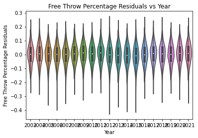

```python
m = line.params.year
a = line.params.Intercept

df['expected'] = 0.0
for i, j in df.iterrows():
    expectation = m * (j['year']) + a
    df.at[i, 'expected'] = expectation
df['residuals'] = df['avg_FT_PCT'] - df['expected']

sns.violinplot(x = 'year', y = 'residuals', data = df)
plt.title("Free Throw Percentage Residuals vs Year")
plt.xlabel("Year")
plt.ylabel("Free Throw Percentage Residuals")
```

### Section 4.5: Residuals of Total Assists

```python
line = ols(formula = "total_assists ~ year ", data = df).fit()
print (line.summary())
```

```
                            OLS Regression Results
==============================================================================
Dep. Variable:          total_assists   R-squared:                       0.080
Model:                            OLS   Adj. R-squared:                  0.080
Method:                 Least Squares   F-statistic:                     2169.
Date:                Sun, 19 Dec 2021   Prob (F-statistic):               0.00
Time:                        11:26:58   Log-Likelihood:                -85431.
No. Observations:               24925   AIC:                         1.709e+05
Df Residuals:                   24923   BIC:                         1.709e+05
Df Model:                           1
Covariance Type:            nonrobust
==============================================================================
                 coef    std err          t      P>|t|      [0.025      0.975]
------------------------------------------------------------------------------
Intercept   -803.2319     18.191    -44.155      0.000    -838.888    -767.576
year           0.4210      0.009     46.572      0.000       0.403       0.439
==============================================================================
Omnibus:                      139.678   Durbin-Watson:                   1.933
Prob(Omnibus):                  0.000   Jarque-Bera (JB):              142.693
Skew:                           0.177   Prob(JB):                     1.03e-31
Kurtosis:                       3.110   Cond. No.                     7.75e+05
==============================================================================

Notes:
[1] Standard Errors assume that the covariance matrix of the errors is correctly specified.
[2] The condition number is large, 7.75e+05. This might indicate that there are
strong multicollinearity or other numerical problems.
```

Annually, the amount of assists in the NBA increases by approximately 0.4210 assists.

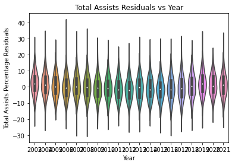

```python
m = line.params.year
a = line.params.Intercept

df['expected'] = 0.0
for i, j in df.iterrows():
    expectation = m * (j['year']) + a
    df.at[i, 'expected'] = expectation
df['residuals'] = df['total_assists'] - df['expected']

sns.violinplot(x = 'year', y = 'residuals', data = df)
plt.title("Total Assists Residuals vs Year")
plt.xlabel("Year")
plt.ylabel("Total Assists Percentage Residuals")
```

### Section 4.6: Residuals of Total Rebounds

```python
line = ols(formula = "total_rebounds ~ year ", data = df).fit()
print (line.summary())
```

```
                            OLS Regression Results
==============================================================================
Dep. Variable:         total_rebounds   R-squared:                       0.057
Model:                            OLS   Adj. R-squared:                  0.057
Method:                 Least Squares   F-statistic:                     1515.
Date:                Sun, 19 Dec 2021   Prob (F-statistic):          8.40e-322
Time:                        11:27:03   Log-Likelihood:                -91011.
No. Observations:               24925   AIC:                         1.820e+05
Df Residuals:                   24923   BIC:                         1.820e+05
Df Model:                           1
Covariance Type:            nonrobust
==============================================================================
                 coef    std err          t      P>|t|      [0.025      0.975]
------------------------------------------------------------------------------
Intercept   -800.4346     22.756    -35.175      0.000    -845.037    -755.832
year           0.4402      0.011     38.925      0.000       0.418       0.462
==============================================================================
Omnibus:                      264.905   Durbin-Watson:                   1.967
Prob(Omnibus):                  0.000   Jarque-Bera (JB):              287.095
Skew:                           0.224   Prob(JB):                     4.55e-63
Kurtosis:                       3.276   Cond. No.                     7.75e+05
==============================================================================

Notes:
[1] Standard Errors assume that the covariance matrix of the errors is correctly specified.
[2] The condition number is large, 7.75e+05. This might indicate that there are
strong multicollinearity or other numerical problems.
```

Annually, the amount of rebounds in the NBA increases by approximately 0.4402 rebounds.

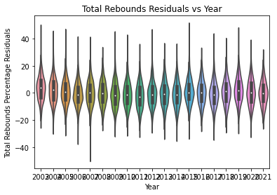

```python
m = line.params.year
a = line.params.Intercept

df['expected'] = 0.0
for i, j in df.iterrows():
    expectation = m * (j['year']) + a
    df.at[i, 'expected'] = expectation
df['residuals'] = df['total_rebounds'] - df['expected']

sns.violinplot(x = 'year', y = 'residuals', data = df)
plt.title("Total Rebounds Residuals vs Year")
plt.xlabel("Year")
plt.ylabel("Total Rebounds Percentage Residuals")
```

# Part 5: Reflection and Conclusion